# PBL Project Part 3, 4, and 5

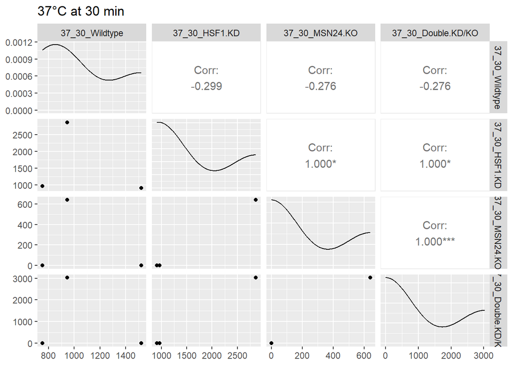

```r
summarizedReplicates %>%
  filter(summarizedReplicates$heatshock_of_interest.gene_id == "YGL073W" |
         summarizedReplicates$heatshock_of_interest.gene_id == "YMR037C" |
         summarizedReplicates$heatshock_of_interest.gene_id == "YKL062W") %>%
  select(`37_30_Wildtype`, `37_30_HSF1.KD`, `37_30_MSN24.KO`, `37_30_Double.KD/KO`) %>%
  ggpairs(title = "37°C at 30 min")
```

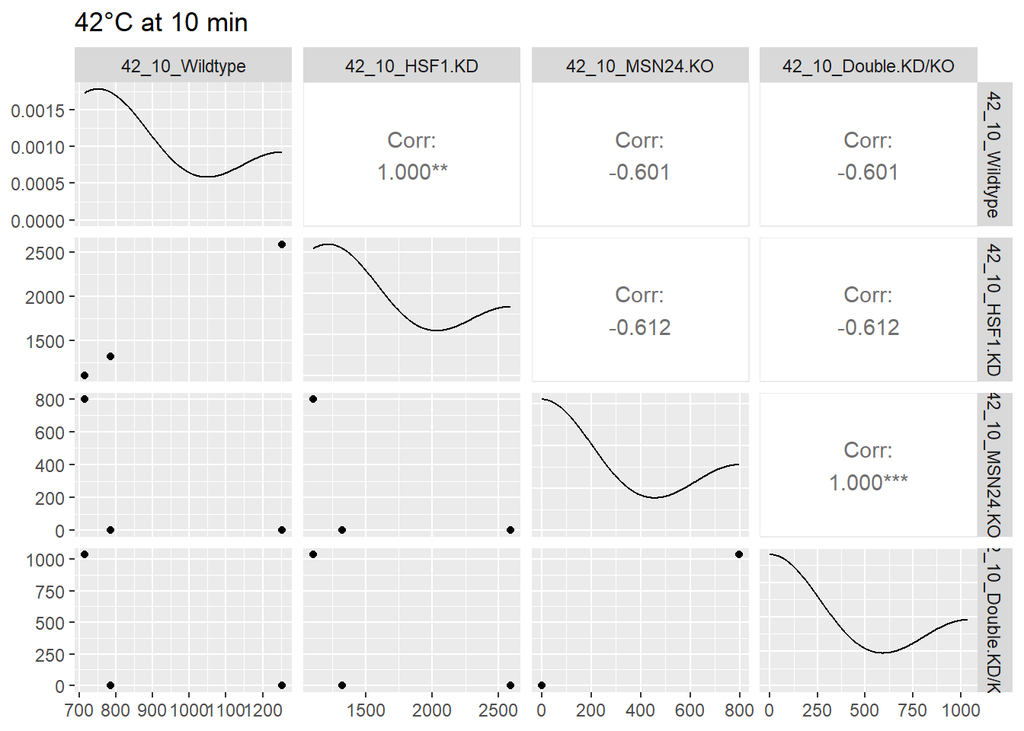

```r
summarizedReplicates %>%
  filter(summarizedReplicates$heatshock_of_interest.gene_id == "YGL073W" |
         summarizedReplicates$heatshock_of_interest.gene_id == "YMR037C" |
         summarizedReplicates$heatshock_of_interest.gene_id == "YKL062W") %>%
  select(`42_10_Wildtype`, `42_10_HSF1.KD`, `42_10_MSN24.KO`, `42_10_Double.KD/KO`) %>%
  ggpairs(title = "42°C at 10 min")
```

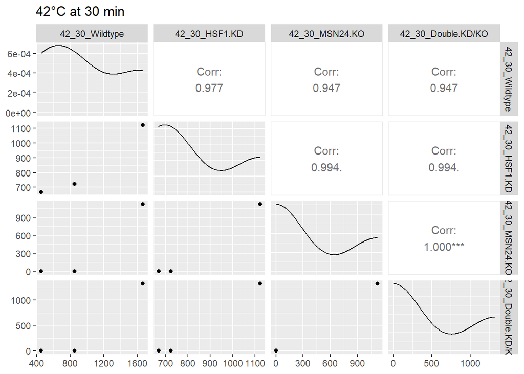

```r
summarizedReplicates %>%
  filter(summarizedReplicates$heatshock_of_interest.gene_id == "YGL073W" |
         summarizedReplicates$heatshock_of_interest.gene_id == "YMR037C" |
         summarizedReplicates$heatshock_of_interest.gene_id == "YKL062W") %>%
  select(`42_30_Wildtype`, `42_30_HSF1.KD`, `42_30_MSN24.KO`, `42_30_Double.KD/KO`) %>%
  ggpairs(title = "42°C at 30 min")
```

## Some more scatter matrices, with all direct interactors of HSF1 and MSN2/4

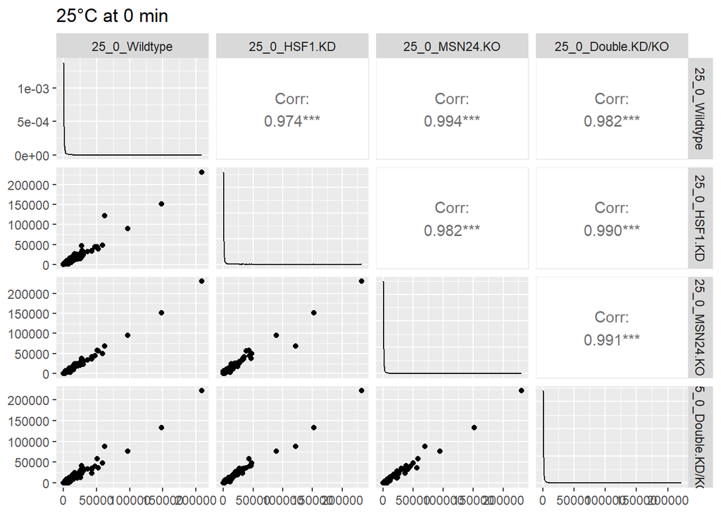

```r
library(GGally)

summarizedReplicates %>%
  select(`25_0_Wildtype`, `25_0_HSF1.KD`, `25_0_MSN24.KO`, `25_0_Double.KD/KO`) %>%
  ggpairs(title = "25°C at 0 min")
```

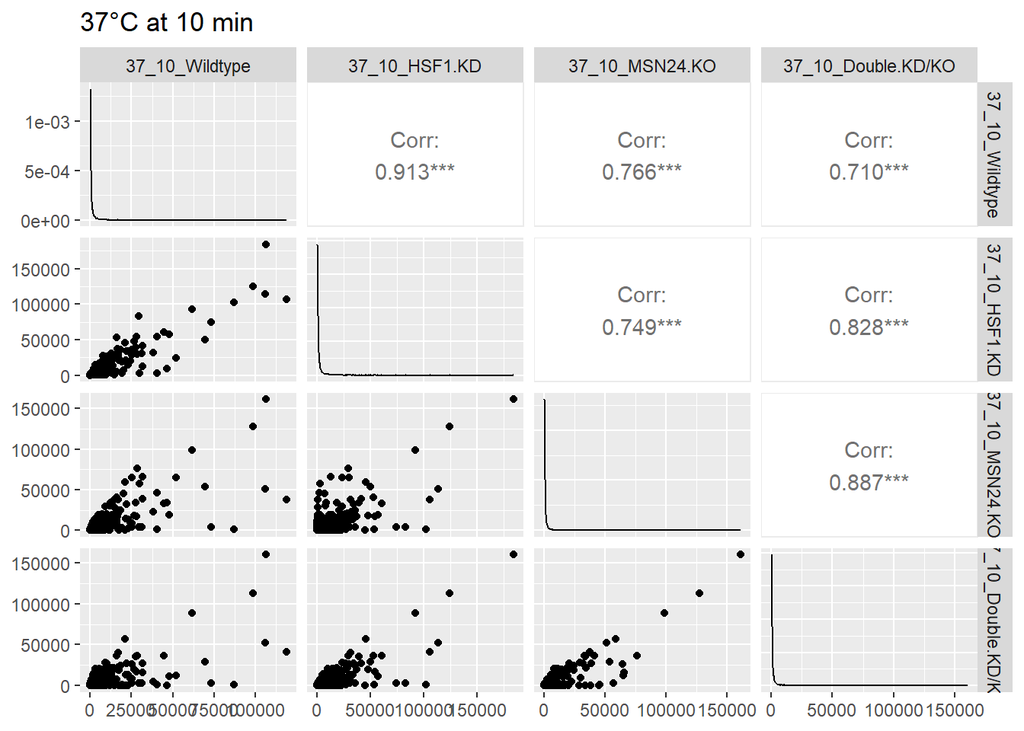

```r
summarizedReplicates %>%
  select(`37_10_Wildtype`, `37_10_HSF1.KD`, `37_10_MSN24.KO`, `37_10_Double.KD/KO`) %>%
  ggpairs(title = "37°C at 10 min")
```

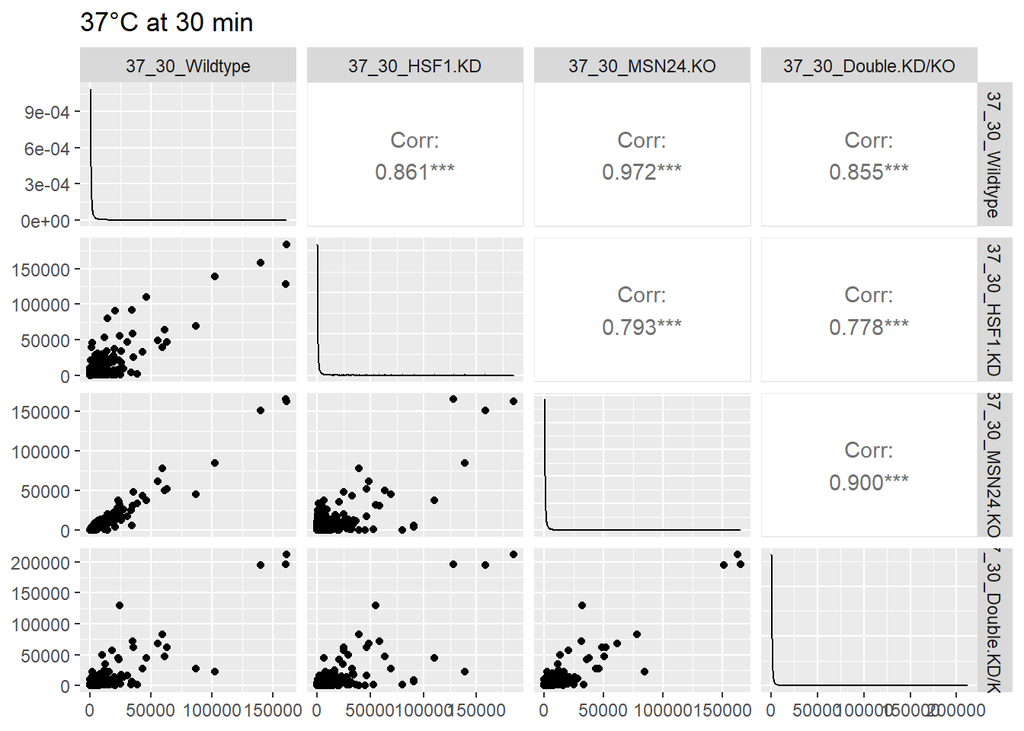

```r
summarizedReplicates %>%
  select(`37_30_Wildtype`, `37_30_HSF1.KD`, `37_30_MSN24.KO`, `37_30_Double.KD/KO`) %>%
  ggpairs(title = "37°C at 30 min")
```

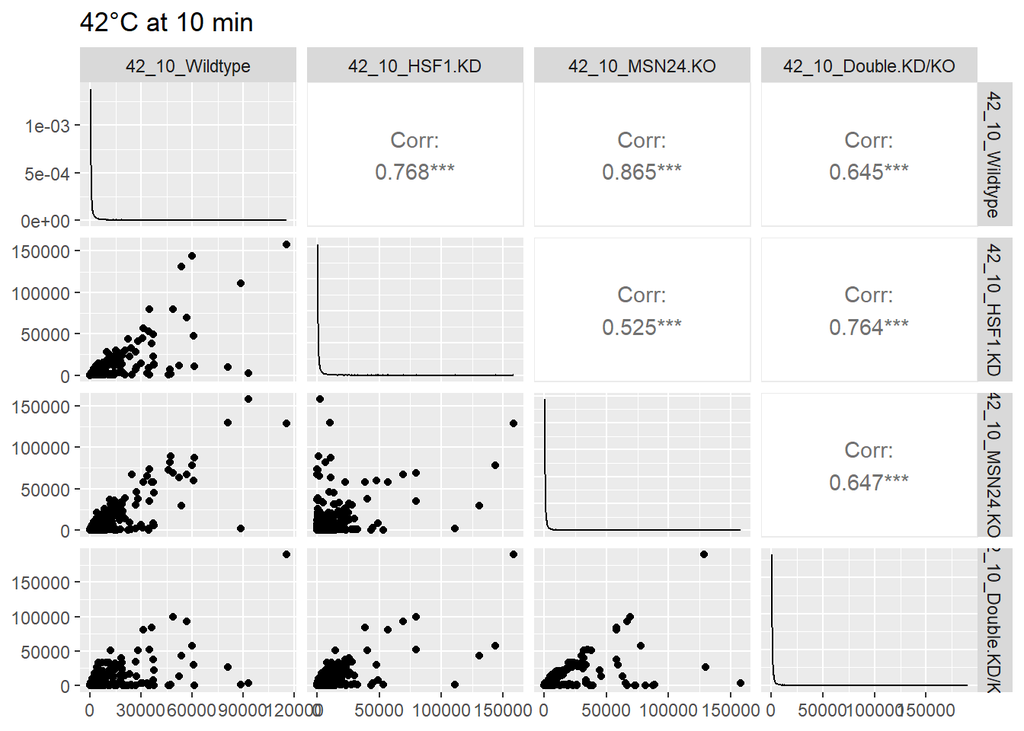

```r
summarizedReplicates %>%
  select(`42_10_Wildtype`, `42_10_HSF1.KD`, `42_10_MSN24.KO`, `42_10_Double.KD/KO`) %>%
  ggpairs(title = "42°C at 10 min")
```

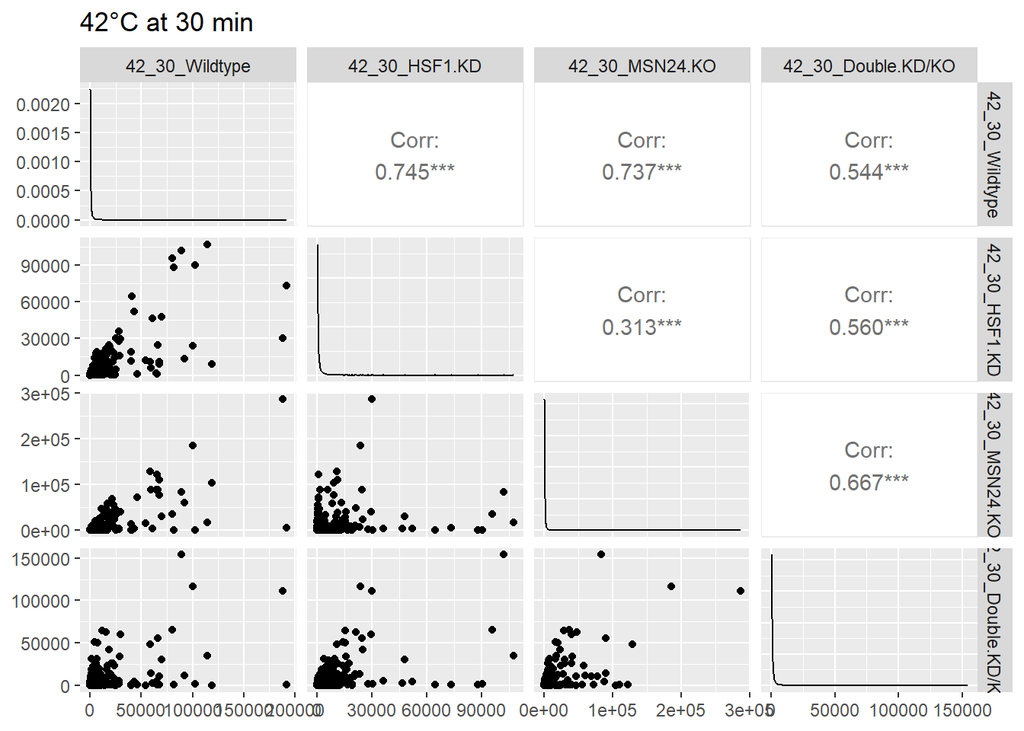

```r
summarizedReplicates %>%
  select(`42_30_Wildtype`, `42_30_HSF1.KD`, `42_30_MSN24.KO`, `42_30_Double.KD/KO`) %>%
  ggpairs(title = "42°C at 30 min")
```

## Use DESeq2

First of all, we installed the packages needed to use the tool.

```r
if (!require("BiocManager", quietly = TRUE))
    install.packages("BiocManager")

BiocManager::install("DESeq2")
```

Afterwards, we searched for some tutorials for how to use it.

For DEseq2 “non-normalized sequence read counts at either the gene or transcript level” [(Differential expression with DEseq2 | Griffith Lab)](https://genviz.org/module-04-expression/0004/02/01/DifferentialExpression/) can be analyzed. Hence, we can use the package to analyze our `complex_yeast_heatshock` data.

We used the Help window in RStudio and looked for “DEseq2” to find relevant functions for our data. There we saw the function `DEseqDataSetFromMatrix()` which might be useful to read in our data-frame. In the next code chunk we will try some things with that.

## DESeq and Fold Changes (Holmes & Huber, Chapter 8)

For the analysis, we will analyze the data according to the temperature. For that we had to transform the data into the correct format via `DESeqDataFromMatrix()` and could then use the DESeq-method of the package to create some interesting plots and get a list of genes and their fold changes throughout the different conditions.

```r
library(DESeq2)
library(tidyverse)

# set proper col and rownames
countData <- complex_yeast_heatshock %>% column_to_rownames(var= "gene_id")
colData <- sample_mapping %>% column_to_rownames(var = "sample")

# convert object
deseqData <- DESeqDataSetFromMatrix(countData = countData[, rownames(colData)],
                                    colData = colData, ~temperature)
class(deseqData)
```

```
## [1] "DESeqDataSet"
## attr(,"package")
## [1] "DESeq2"
```

```r
is(deseqData, "SummarizedExperiment")
```

```
## [1] TRUE
```

```r
# get results from DESeq
res <- DESeq(deseqData)
result <- results(res)

res[order(result$padj), ] |> head()
```

```
## class: DESeqDataSet
## dim: 6 60
## metadata(1): version
## assays(6): counts mu ... replaceCounts replaceCooks
## rownames(6): YBR018C YOR048C ... YJL122W YLR146C
## rowData names(23): baseMean baseVar ... maxCooks replace
## colnames(60): 25_0_Double.KD/KO_r1 25_0_Double.KD/KO_r2 ...
##   42_30_Wildtype_r2 42_30_Wildtype_r3
## colData names(6): temperature time ... sizeFactor replaceable
```

### Histogram of p-values

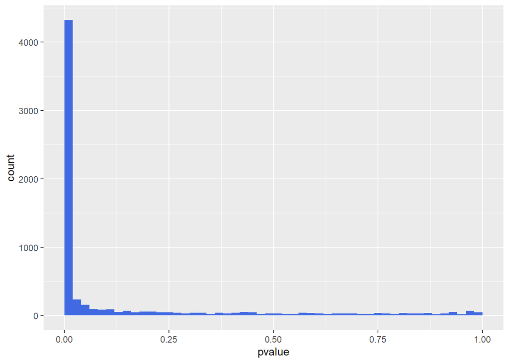

```r
ggplot(as(result, "data.frame"), aes(x = pvalue)) +
  geom_histogram(binwidth = 0.02, fill = "Royalblue", boundary = 0)
```

### MA plot

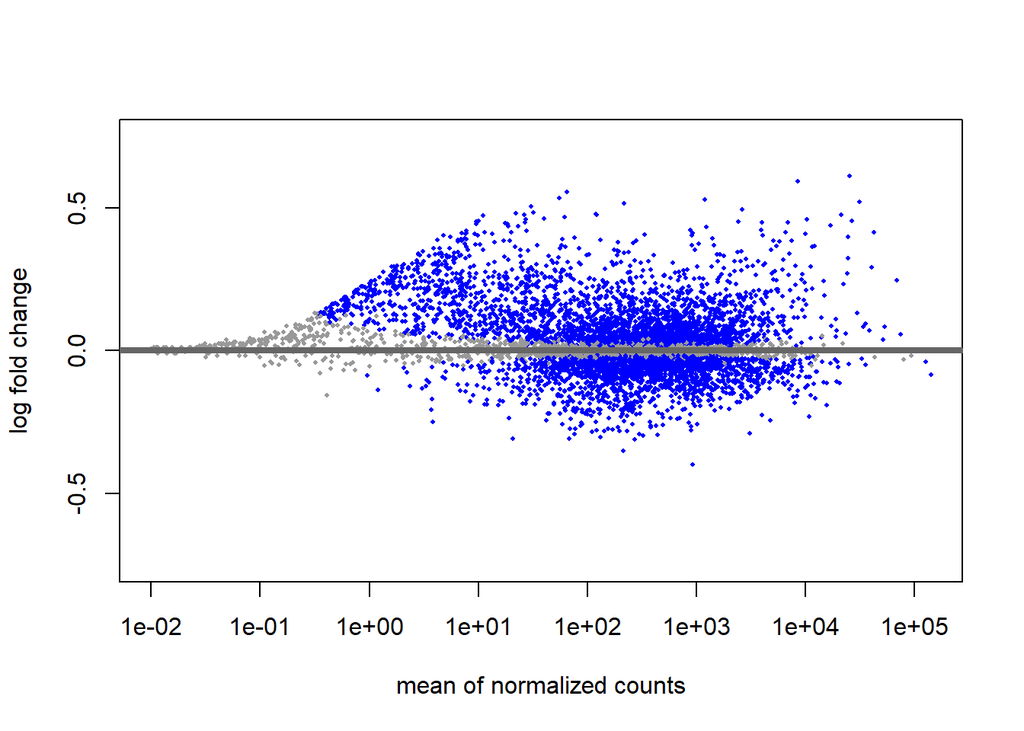

```r
plotMA(res, ylim = c(-0.75, 0.75))
```

### PCA plot

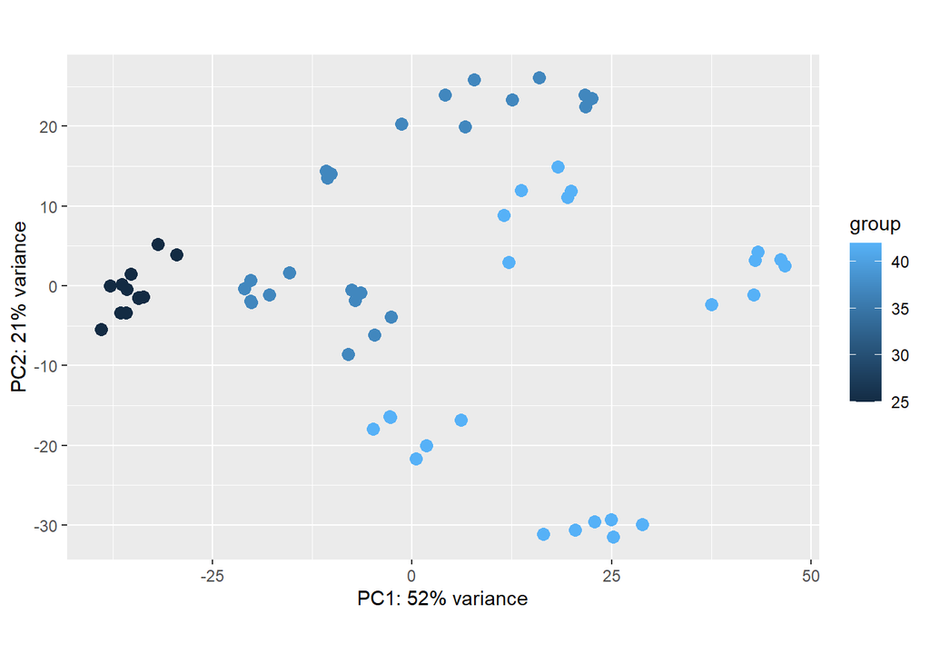

```r
pas_rlog <- rlogTransformation(res)
plotPCA(pas_rlog, intgroup = c("temperature")) + coord_fixed()
```

### Heatmap out of DESeqData results

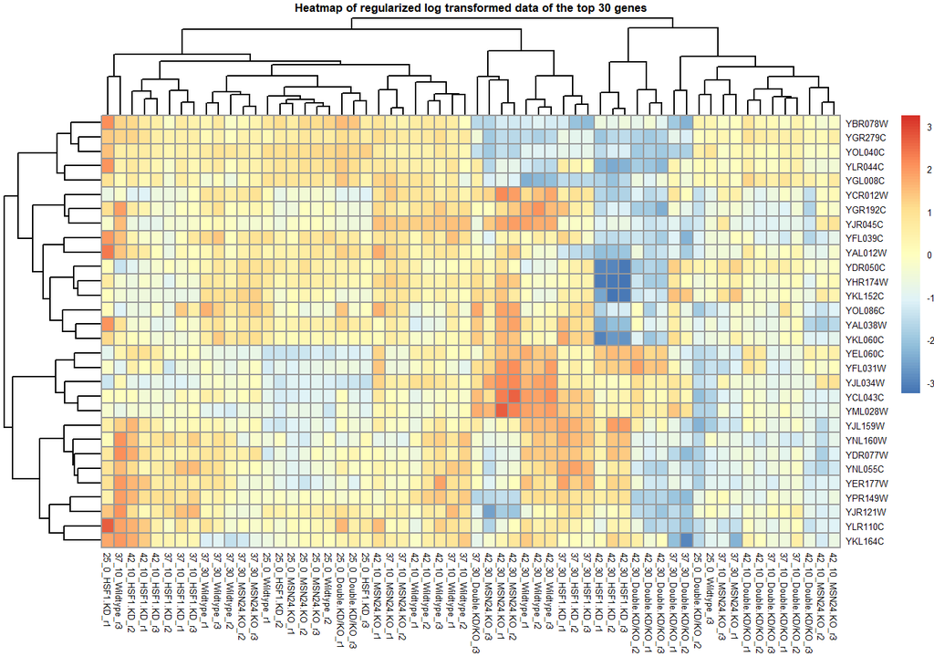

```r
library("pheatmap")
select <- order(rowMeans(assay(pas_rlog)), decreasing = TRUE)[1:30]
pheatmap(assay(pas_rlog)[select, ], scale = "row", fontsize = 5,
         main = "Heatmap of regularized log transformed data of the top 30 genes")
```

### Calculated fold changes of DESeq result in dataframe (summary)

```r
tableResult <- as.data.frame(result)
summary(tableResult)
```

```
##     baseMean         log2FoldChange        lfcSE             stat
##  Min.   :     0.00   Min.   :-0.3987   Min.   :0.0044   Min.   :-19.1219
##  1st Qu.:    26.73   1st Qu.:-0.0342   1st Qu.:0.0113   1st Qu.: -2.7466
##  Median :   192.28   Median : 0.0119   Median :0.0157   Median :  0.7456
##  Mean   :   863.92   Mean   : 0.0310   Mean   :0.0239   Mean   :  0.7108
##  3rd Qu.:   621.13   3rd Qu.: 0.0805   3rd Qu.:0.0242   3rd Qu.:  4.3363
##  Max.   :141184.40   Max.   : 0.6116   Max.   :0.2359   Max.   : 19.6684
##                      NA's   :542       NA's   :542      NA's   :542
##      pvalue            padj
##  Min.   :0.0000   Min.   :0.0000
##  1st Qu.:0.0000   1st Qu.:0.0000
##  Median :0.0003   Median :0.0006
##  Mean   :0.1347   Mean   :0.1501
##  3rd Qu.:0.1080   3rd Qu.:0.1440
##  Max.   :0.9992   Max.   :0.9992
##  NA's   :542      NA's   :542
```